# Aula 4 - Visualização de dados

Vitor Rios

11 de novembro de 2017

# Visualizar seus dados pode ser a parte mais importante da sua análise

Fazer gráficos no R pode dar (muito) trabalho, mas os resultados valem a pena

Gráficos no R são baseados em dispositivos. O dipositivo padrão é a tela, mas podem ser arquivos, cada tipo de arquivo gráfico sendo um dispositivo diferente

No RStudio, gráficos são plotados na aba plots, mas podem ser abertos em janelas separadas, usando a função `x11()` (Linux e Windows), `windows()` (Windows somente) ou `quartz()` (Macintosh)

Os tipos padrão de gráficos disponíveis são `postscript()` para arquivo postscript, extensão `.ps` ou `.eps`  
`pdf()` salva o gráfico num arquivo `.pdf`  
`pictex()` salva o gráfico no formato LaTeX/PicTeX  
`xfig()` salva o gráfico no formato `.XFIG`  
`bmp()`, `bitmap()` salva um arquivo `.bitmap` (precisa de GhostScript instalado).  
`X11()` plota numa janela via sistema gráfico X11  
`png()` salva o gráfico no formato `.PNG` `tiff()` salva o gráfico no formato `.tiff` `jpeg()` salva o gráfico no formato `.jpg` `svg()` salva o gráfico no formato `.svg`

# Gravando o gráfico num arquivo

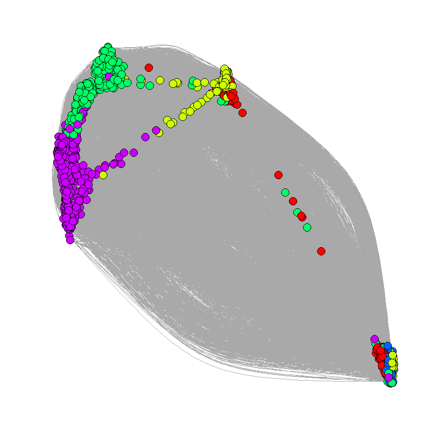

Grafo

```r
# Chame o tipo de arquivo desejado, passando informações de tamanho, resolução, tipo de fonte, e nome de arquivo
png("SocialNetworkExample.png",width = 900,height = 900)

#plote seu gráfico normalmente, ele será escrito no arquivo e não irá aparecer na tela
plot(graph.subset,
     layout= layout_nicely(graph=graph.subset),
     vertex.label=NA,
     vertex.color=colors[membership(graph.subset.modulos)],
     vertex.size = 5,
     )
#feche o dispositivo, usando dev.off(), senão o arquivo ficará corrompido
dev.off()
```

Função básica e poderosa (e feia): `plot()`

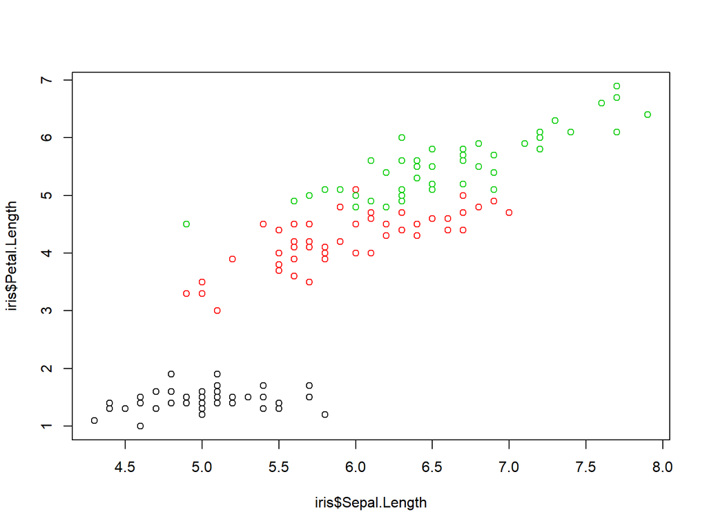

```r
plot(x= iris$Sepal.Length, y=iris$Petal.Length,col=iris$Species)
```

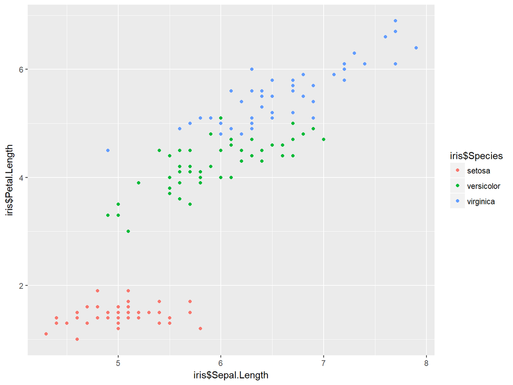

```r
library(ggplot2) #pacote especial para fazer graficos, com interface mais amigavel
qplot(x= iris$Sepal.Length, y=iris$Petal.Length, color=iris$Species)
```

# A função `plot()` tem dezenas de opções para controlar cada detalhe mínimo do gráfico

Principais: - x - y - type - main - xlab - ylab - xlim - ylim xaxt bty pch cex

| Parâmetro | Controla | valores |
| --- | --- | --- |
| x | valores a serem plotados em x |  |
| y | valores a serem plotados em x |  |
| type | tipo de gráfico (ponto, linhas, etc) | “p”,“l”,“b”… |
| lty | tipo de linha (pontilhada, tracejada, etc) | “blank”, “solid”, “dashed”, “dotted”, “dotdash”, “longdash”, ou “twodash” |
| pch | tipo de ponto (bola, triangulo, quadrado, etc) | “p”,“l”,“b”… |
| col | cor dos símbolos | “red”, “black”, “1”, RGB |
| col.axis, col.lab, col.main | cor dos textos | “red”, “black”, “1”, RGB |

| Parâmetro | Controla | valores |
| --- | --- | --- |
| main | título do gráfico | “texto entre aspas” |
| xlab | rótulos do eixo x | “texto entre aspas” |
| ylab | rótulos do eixo y | “texto entre aspas” |
| cex | tamanho das letras, em proporção | cex = 1 -> 100%, cex = 0.5 ->50%, etc |
| cex.axis, cex.lab, cex.main | eixos, rotulos dos eixos, título | cex.axis = 1 -> 100%, cex.axis = 0.5 ->50%, etc |
| bty | linhas de contorno do gráfico | “o”, “l”, “7”, “c”, “u”, “]”, “n” |
| ylab | rótulos do eixo y | “texto entre aspas” |
| ylab | rótulos do eixo y | “texto entre aspas” |

# Função `par()` e função `axis()`

`par()` estabelece os parâmetros para todos os gráficos que se seguem a ela exceto parâmetros de intervalo de dados a serem plotado. Usada para definir gráficos com vários painéis, margens e área do gráfico. Usada antes de qualquer `plot()`

`axis()` define todos os parâmetros para os eixos, usada depois de `plot(dados, xaxt = "n")` (para eixo x) ou `plot(dados, yaxt = "n")` (para eixo y)

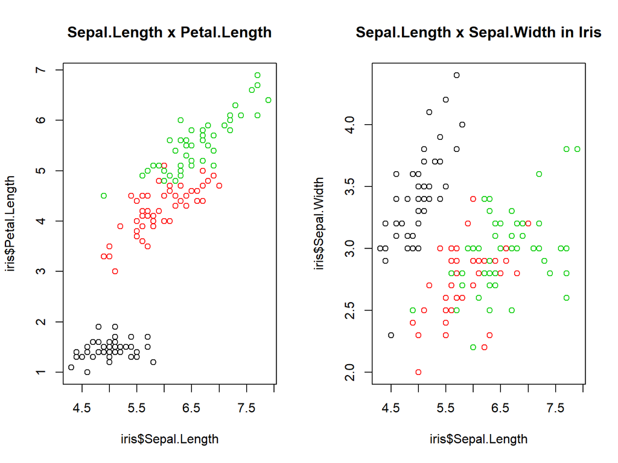

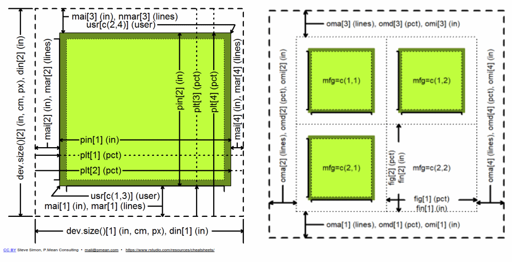

fonte:https://www.rstudio.com/resources/cheatsheets/

```r
par(mfrow=c(1,2))      #linhas, colunas

plot(x=iris$Sepal.Length, y=iris$Petal.Length,        #primeiro gráfico
     col = iris$Species,
     main = "Sepal.Length x Petal.Length")

plot(x=iris$Sepal.Length, y=iris$Sepal.Width,         #segundo gráfico
     col = iris$Species,
     main = "Sepal.Length x Sepal.Width in Iris")
```

# Funções que adicionam elemento a gráficos

`abline()` adiciona uma linha, definida por intercepto e inclinação, ou por valores de posição horizontal (h) e vertical (v)

`segments((x0, y0, x1, y1)` adiciona um segmento indo de (x0,y0) até (x1,y1)

`arrows(x0, y0, x1 , y1 , length, angle = 30)` adiciona uma seta a um gráfico. `length`é o comprimento da seta e `angle` é o angulo da ponta da seta

`points(x, y, pch)` adiciona pontos nas coordenadas x e y. `pch` é o tipo de simbolo utilizado

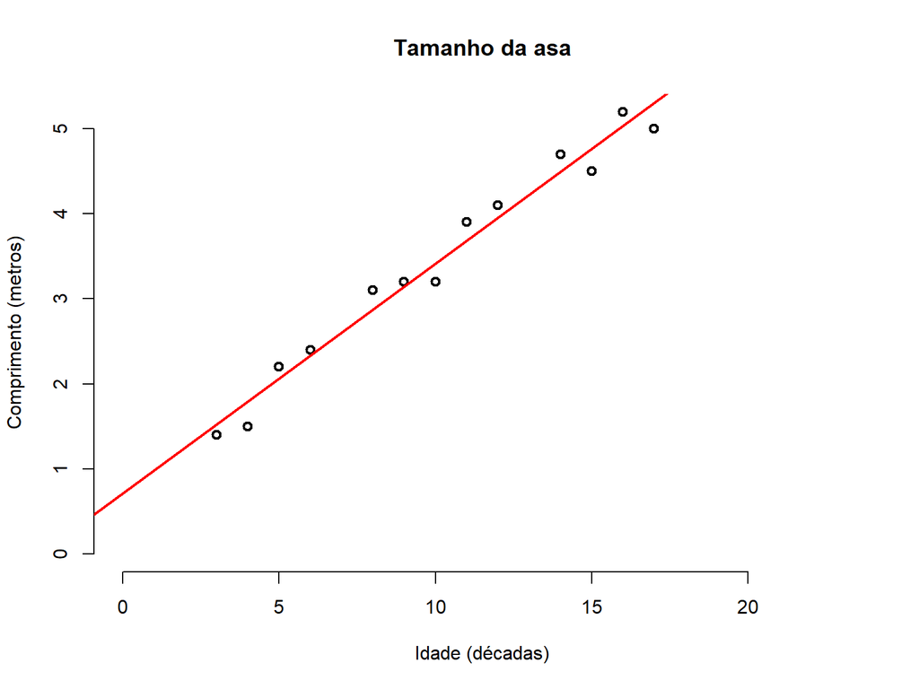

```r
plot(TamanhoDaAsa ~ Idade, xlab = "Idade (décadas)",
     ylab = "Comprimento (metros)",
     main = "Tamanho da asa"
     , bty = "n"
     , xlim = c(0, 23), ylim = c(0, max(TamanhoDaAsa))
     , lwd = 2
)
abline(modelo, col = "red", lwd = 2)
```

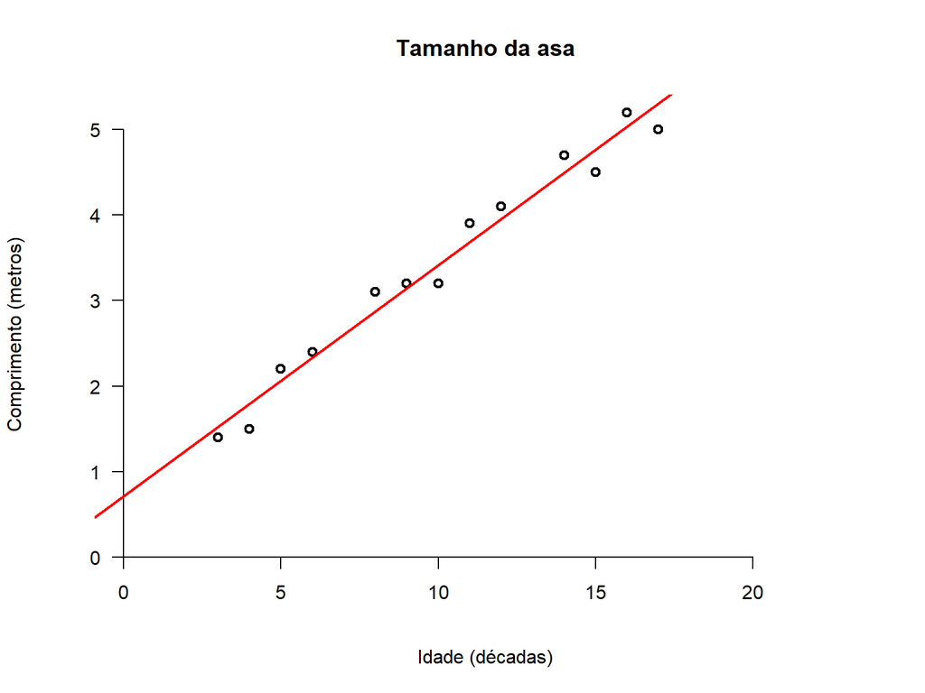

```r
modelo=lm(TamanhoDaAsa ~ Idade)
par(bty = "n" , lwd = 2)
plot(TamanhoDaAsa ~ Idade, xlab = "Idade (décadas)",
     ylab = "Comprimento (metros)",
     main = "Tamanho da asa"
     , xlim = c(0, 23)
     , ylim = c(0, max(TamanhoDaAsa))
     , yaxt = "n"  # "n" não plota o eixo, pois iremos alterá-lo com axis()
     , xaxt = "n"
)
axis(1, pos = 0)
axis(2, pos = 0, las=2)
abline(modelo, col = "red", lwd = 2)
```

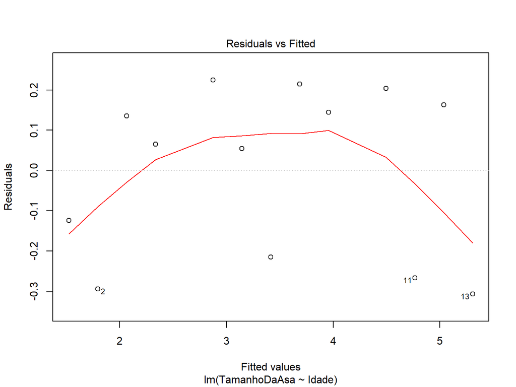

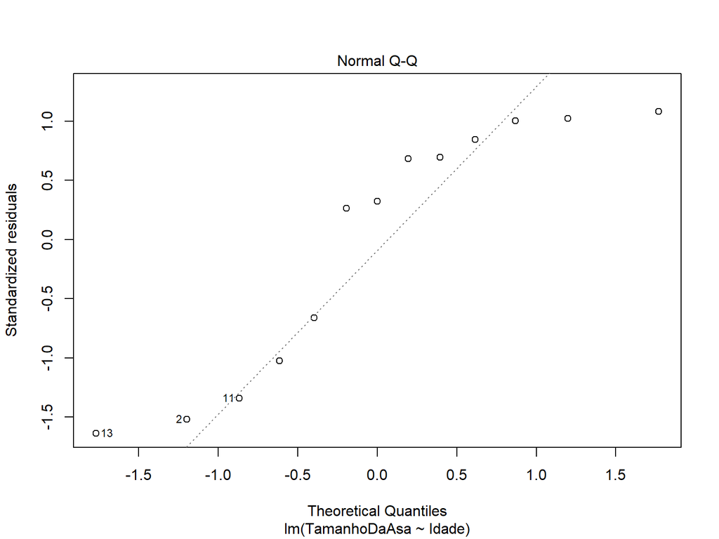

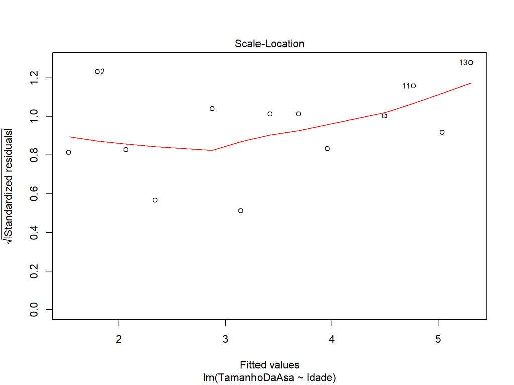

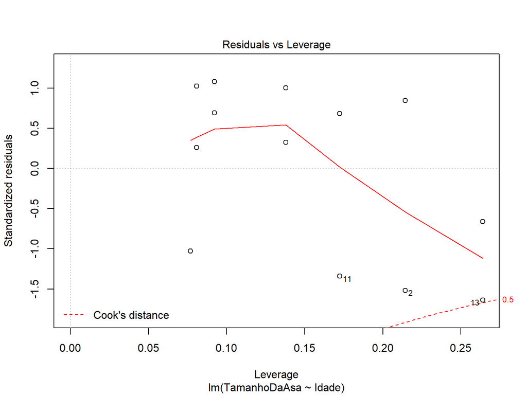

```r
plot(modelo)
```

# Para plotar médias com barras de desvio padrão

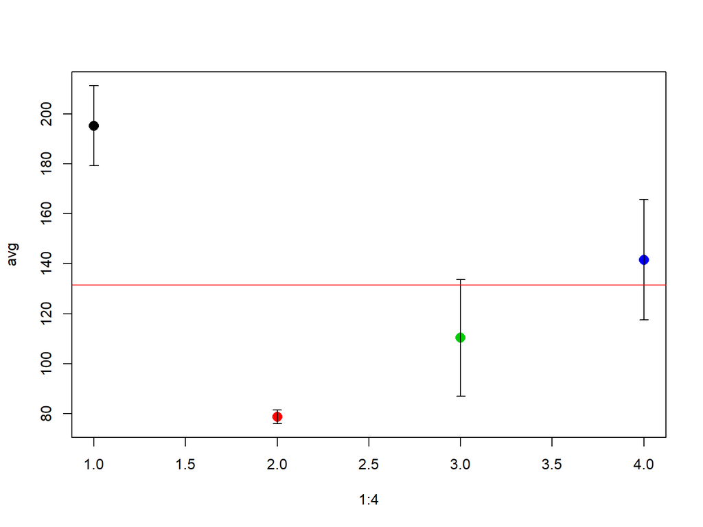

```r
m1=mean(dragoes$y[dragoes$x=="aventureiros"]);m2=mean(dragoes$y[dragoes$x=="fazendeiros"])
m3=mean(dragoes$y[dragoes$x=="vacas"]);m4=mean(dragoes$y[dragoes$x=="virgens"],na.rm = T)
s1=sd(dragoes$y[dragoes$x=="aventureiros"]);s2=sd(dragoes$y[dragoes$x=="fazendeiros"])
s3=sd(dragoes$y[dragoes$x=="vacas"]);s4=sd(dragoes$y[dragoes$x=="virgens"],na.rm = T)
avg=c(m1,m2,m3,m4)
sdev=c(s1,s2,s3,s4)
plot(x= 1:4, y= avg,cex=1.5,pch=16, col=1:4,ylim=range(c(avg-sdev, avg+sdev)))
arrows(x0=1:4, y0=avg-sdev, x1=1:4, y1=avg+sdev, length=0.05, angle=90, code=3)
abline(h=mean(avg), col="red")#media total
```

# Boxplot

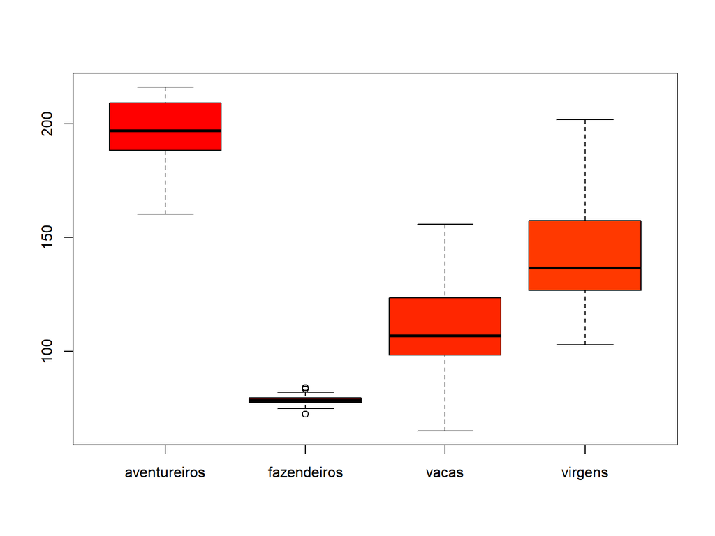

```r
boxplot(dragoes$y ~ dragoes$x, col=rainbow(length(dragoes$x)))
```

A função boxplot permite comparar os intervalos de confiança 95% das medianas: se os entalhes não se sobrepuserem, há forte evidência de que as medianas são diferentes

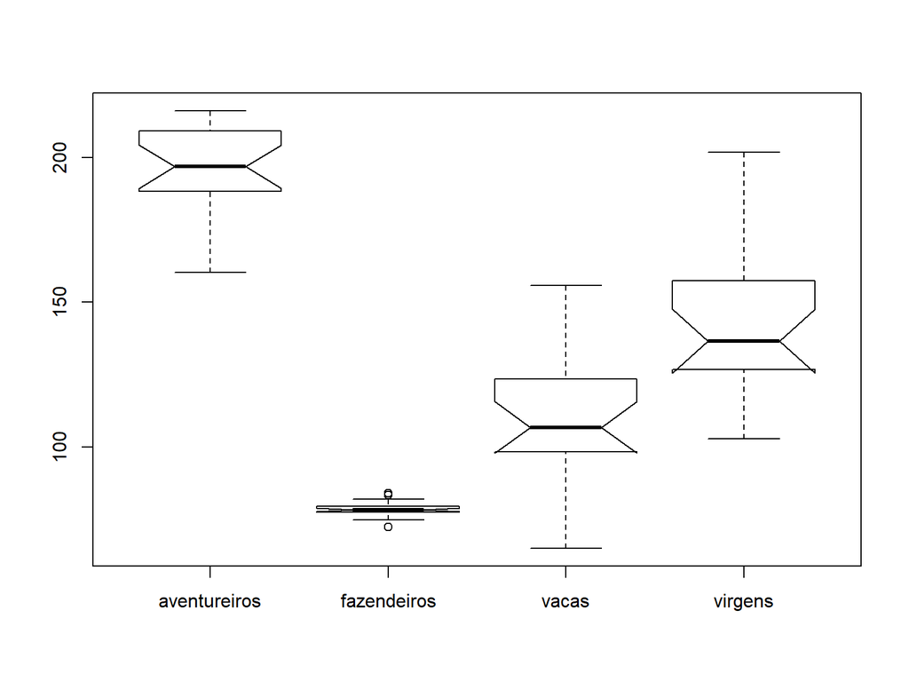

```r
boxplot(dragoes$y ~ dragoes$x, notch=T)
```

# Função `aggregate()`

A função `summary` nos dá muitas informações sobre a estrutura dos nossos dados, mas tudo. Em particular, desvio padrão, erro padrão da média, curtose, e assimetria devem ser calculados à mão, principalmente se quisermos essas estatísticas agrupadas por níveis de um fator. Para isso usamos a função `aggregate()`

`aggregate(x, by, FUN, ...)`  
`x` é a coluna do dataframe que ser quer agrupar  
`by` é a coluna que contém os níveis dos grupos que se quer usar  
`FUN` é a função que se quer aplicar nos grupos, sem parênteses  
`...` são os argumentos que serão passados para a função `FUN`

```r
media.por.comida = aggregate(x=dragoes$y,by = list(dragoes$x), FUN = mean, na.rm=T)
media.por.comida
```

```
##        Group.1        x
## 1 aventureiros 195.3093
## 2  fazendeiros  78.6809
## 3        vacas 110.3509
## 4      virgens 141.6241
```

```r
sd.por.comida = aggregate(x=dragoes$y,by = list(dragoes$x), FUN = sd, na.rm=T)
sd.por.comida
```

```
##        Group.1         x
## 1 aventureiros 16.119541
## 2  fazendeiros  2.749037
## 3        vacas 23.354194
## 4      virgens 24.159891
```

```r
files_to_read=list.files(pattern = reg.exp)
if (length(files_to_read)!=0)
{
  for (r in 1:(length(files_to_read)))
  {temp_valores_replicas[,r] <- read.table(files_to_read[r],  header = FALSE)}
  graphtype=NA#creating plot names
  if(type=="g"){graphtype=" with general recognition "}
  if (type=="i") {graphtype=" with Individual Recognition "}
  if (type=="nr") {graphtype=" with No Recognition "}
  plotname =paste(metrica,graphtype, ", mundo = ", world_size, ", mem length = ", as.numeric(mem_length), ", mem modifier = ", as.numeric (modifier),".tiff", sep = "")
  if("plots"%in%dir()==FALSE) dir.create("plots") #se não existir, cria diretorio /plots
  #C:/Users/Vitor/Desktop/100replicas/resultados
  filename = file.path("C:", "Users", "Vitor","Desktop", "100replicas", "resultados", "plots" ,plotname)

  tiff(filename ,width = 7.5 ,height = 5,units = "in"
       ,res=300, compression = "lzw",type="cairo", antialias = "default"
       )
  y=max(temp_valores_replicas,na.rm = TRUE)+1
  par(mar=c(4,5,1,2)+0.1)
  plot( #plota primeira linha
    temp_valores_replicas[,1]
    , ylim=c(-1,y)
    , xlab = "Time steps", ylab = metrica, type="l"
    ,bty="l",family="Arial",cex.lab=1.5
  )
  for (p in 2:ncol(temp_valores_replicas))
  {lines(temp_valores_replicas[p],col=p)} #plota resto das linhas
  dev.off()
}
```